# Slowdown hypothesis

# Introduction

The aim of this notebook is to extend and update the analyses presented in [White (2002)](https://onlinelibrary.wiley.com/doi/pdf/10.1111/j.1728-4457.2002.00059.x).

The figures/analyses are as follows:

- Table 1: How well does a linear time trend in 21 high-income countries explain change in life exptectancy at birth between 1955 and 1991?
- Figure 1: Life expectancy at birth over time, unweighted averages of 21 high-income countries, 1955-96
- Table 2: Change in age-specific death rates between 1955 and 1991, unweighted averages for 21 high-income countries
- Figure 2: Annual change in life expectancy at birth, average of 21 high-income countries, 1955-96
- Figure 3: relationship between life expectancy at birth in 1995 and annual change in life expectancy in 21 high-income countries, 1955-96
- Table 3: Life expectancy at birth and difference from average $e_{0}$ in 21 high-income countries, 1955 to 1995
- Figure 4: Variance betwene life expectancies for 21 high-income countries, 1955-96
- Figure 5: Relationship between early (1955-75) and late (1975-95) gains in life expectancy for 21 high-income countries

All but one of the above can be replicated with the period life expectancy data alone

## Prereqs

```r
pacman::p_load(
  tidyverse, HMDHFDplus, here,
  ggrepel, kableExtra, openxlsx
)

dta_e0 <- read_rds(here("tidy_data","e0_period.rds"))
```

## First step: define countries

The high income countries were:

- Australia (AUS)
- Austria (AUT)
- Belgium (BEL)
- Canada (CAN)
- Denmark (DNK)
- Finland (FIN)
- France (FRATNP)
- Germany (West) (DEUTW)
- Greece (GRC)
- Ireland (IRL)
- Italy (ITA)
- Japan (JPN)
- Netherlands (NLD)
- New Zealand (NZL_NP)
- Norway (NOR)
- Portugal (PRT)
- Spain (ESP)
- Sweden (SWE)
- Switzerland (CHE)
- United Kingdom (GBR_NP)
- United States (USA)

```r
source(here("scripts", "country_definitions.R"))
```

# Replications

## Table 1

To do

## Figure 1

Life expectancy at birth over time, unweighted averages of 21 high-income countries, 1955-96

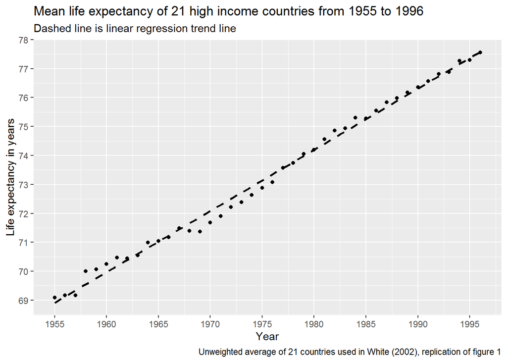

```r
fig_01_dta <- dta_e0 %>%
  filter(code %in% high_income_countries) %>%
  filter(sex == "total") %>%
  filter(between(year, 1955, 1996)) %>%
  group_by(year) %>%
  summarise(mean_e0 = mean(e0, na.rm = T)) %>%
  ungroup()

fig_01_dta %>%
  ggplot(aes(x = year, y = mean_e0)) +
  geom_point() +
  scale_x_continuous(breaks = seq(1955, 2015, by = 5)) +
  scale_y_continuous(breaks = seq(65, 85, by = 1)) +
  stat_smooth(method = "lm", se = F, colour = "black", linetype = "dashed") +
  labs(
    x = "Year",
    y = "Life expectancy in years",
    title = "Mean life expectancy of 21 high income countries from 1955 to 1996",
    subtitle = "Dashed line is linear regression trend line",
    caption = "Unweighted average of 21 countries used in White (2002), replication of figure 1"
  )
```

```r
ggsave(here("figures", "pt1_white_orig.png"), height = 12, width = 20, units = "cm", dpi = 300)
```

And what’s the average improvement per year?

```r
fig_01_dta %>%
  lm(mean_e0 ~ year, data = .) %>%
  summary()
```

```
##
## Call:
## lm(formula = mean_e0 ~ year, data = .)
##
## Residuals:
##      Min       1Q   Median       3Q      Max
## -0.49600 -0.06314  0.03550  0.11334  0.45529
##
## Coefficients:
##               Estimate Std. Error t value Pr(>|t|)
## (Intercept) -3.442e+02  5.446e+00  -63.20   <2e-16 ***
## year         2.113e-01  2.757e-03   76.65   <2e-16 ***
## ---
## Signif. codes:  0 '***' 0.001 '**' 0.01 '*' 0.05 '.' 0.1 ' ' 1
##
## Residual standard error: 0.2165 on 40 degrees of freedom
## Multiple R-squared:  0.9932, Adjusted R-squared:  0.9931
## F-statistic:  5875 on 1 and 40 DF,  p-value: < 2.2e-16
```

Around 0.211 years/year, not the 0.208 given in the paper. (So close enough given changes in data quality and HMD protocol changes)

```r
fig_01_dta %>%
  lm(mean_e0 ~ I(year-1950), data = .) %>%
  summary()
```

```
##
## Call:
## lm(formula = mean_e0 ~ I(year - 1950), data = .)
##
## Residuals:
##      Min       1Q   Median       3Q      Max
## -0.49600 -0.06314  0.03550  0.11334  0.45529
##
## Coefficients:
##                 Estimate Std. Error t value Pr(>|t|)
## (Intercept)    67.855309   0.077832  871.81   <2e-16 ***
## I(year - 1950)  0.211300   0.002757   76.65   <2e-16 ***
## ---
## Signif. codes:  0 '***' 0.001 '**' 0.01 '*' 0.05 '.' 0.1 ' ' 1
##
## Residual standard error: 0.2165 on 40 degrees of freedom
## Multiple R-squared:  0.9932, Adjusted R-squared:  0.9931
## F-statistic:  5875 on 1 and 40 DF,  p-value: < 2.2e-16
```

Now how has this continued?

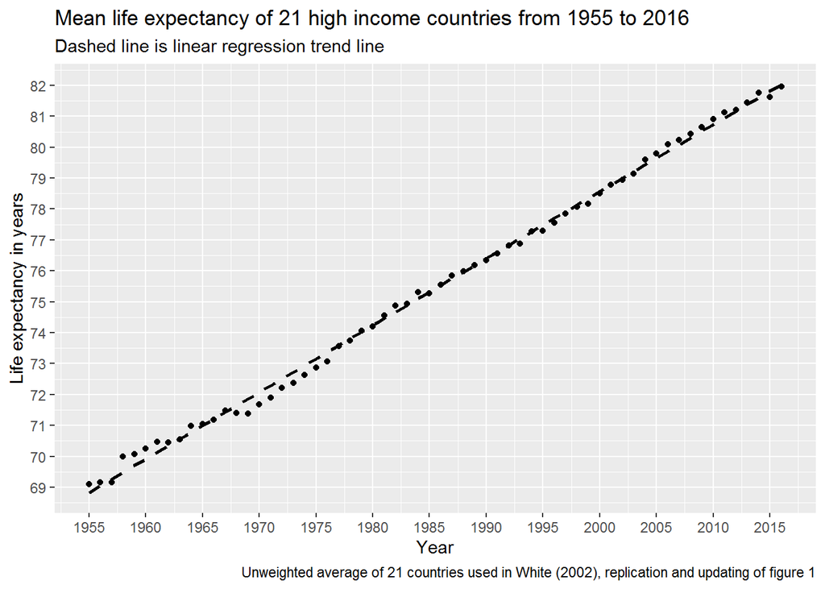

```r
tmp <- dta_e0 %>%
  filter(code %in% high_income_countries) %>%
  filter(sex == "total") %>%
  filter(between(year, 1955, 2016)) %>%
  group_by(year) %>%
  summarise(mean_e0 = mean(e0, na.rm = T)) %>%
  ungroup()

tmp %>%
  ggplot(aes(x = year, y = mean_e0)) +
  geom_point() +
  scale_x_continuous(breaks = seq(1955, 2015, by = 5)) +
  scale_y_continuous(breaks = seq(65, 85, by = 1)) +
  stat_smooth(method = "lm", se = F, colour = "black", linetype = "dashed") +
  labs(
    x = "Year",
    y = "Life expectancy in years",
    title = "Mean life expectancy of 21 high income countries from 1955 to 2016",
    subtitle = "Dashed line is linear regression trend line",
    caption = "Unweighted average of 21 countries used in White (2002), replication and updating of figure 1"
  )
```

```r
ggsave(here("figures", "pt1_white_update.png"), height = 12, width = 20, units = "cm", dpi = 300)
ggsave(here("figures", "e0_limits", "fig_1_a_all_highincome.png"), height = 12, width = 20, units = "cm", dpi = 300)
```

The near perfect linearlity has continued beyond 1996.

What does this look like for the earlier and later period?

```r
tmp %>%
  lm(mean_e0 ~ year, .) %>%
  summary()
```

```
##
## Call:
## lm(formula = mean_e0 ~ year, data = .)
##
## Residuals:
##      Min       1Q   Median       3Q      Max
## -0.48381 -0.07116 -0.00186  0.13909  0.52326
##
## Coefficients:
##               Estimate Std. Error t value Pr(>|t|)
## (Intercept) -3.542e+02  2.824e+00  -125.4   <2e-16 ***
## year         2.164e-01  1.422e-03   152.1   <2e-16 ***
## ---
## Signif. codes:  0 '***' 0.001 '**' 0.01 '*' 0.05 '.' 0.1 ' ' 1
##
## Residual standard error: 0.2004 on 60 degrees of freedom
## Multiple R-squared:  0.9974, Adjusted R-squared:  0.9974
## F-statistic: 2.314e+04 on 1 and 60 DF,  p-value: < 2.2e-16
```

```r
tmp %>%
  filter(year < 1993) %>%
  lm(mean_e0 ~ year, .) %>%
  summary()
```

```
##
## Call:
## lm(formula = mean_e0 ~ year, data = .)
##
## Residuals:
##      Min       1Q   Median       3Q      Max
## -0.49615 -0.13980  0.04021  0.14316  0.45690
##
## Coefficients:
##               Estimate Std. Error t value Pr(>|t|)
## (Intercept) -3.445e+02  6.626e+00  -51.99   <2e-16 ***
## year         2.115e-01  3.357e-03   62.98   <2e-16 ***
## ---
## Signif. codes:  0 '***' 0.001 '**' 0.01 '*' 0.05 '.' 0.1 ' ' 1
##
## Residual standard error: 0.227 on 36 degrees of freedom
## Multiple R-squared:  0.991,  Adjusted R-squared:  0.9908
## F-statistic:  3967 on 1 and 36 DF,  p-value: < 2.2e-16
```

```r
tmp %>%
  filter(year >= 1993) %>%
  lm(mean_e0 ~ year, .) %>%
  summary()
```

```
##
## Call:
## lm(formula = mean_e0 ~ year, data = .)
##
## Residuals:
##      Min       1Q   Median       3Q      Max
## -0.30749 -0.06907 -0.01343  0.08937  0.20771
##
## Coefficients:
##               Estimate Std. Error t value Pr(>|t|)
## (Intercept) -3.732e+02  7.264e+00  -51.38   <2e-16 ***
## year         2.259e-01  3.624e-03   62.34   <2e-16 ***
## ---
## Signif. codes:  0 '***' 0.001 '**' 0.01 '*' 0.05 '.' 0.1 ' ' 1
##
## Residual standard error: 0.1229 on 22 degrees of freedom
## Multiple R-squared:  0.9944, Adjusted R-squared:  0.9941
## F-statistic:  3886 on 1 and 22 DF,  p-value: < 2.2e-16
```

The R-squared value is over 99% for all years, the earlier period, and the latter period.

The rate of annual increase actually increased rather than fell.

Let’s do this for each decade

```r
dta_e0 %>%
  filter(code %in% high_income_countries) %>%
  filter(sex == "total") %>%
  filter(between(year, 1955, 2016)) %>%
  mutate(decade = cut(year, seq(1955, 2015, by = 10), include.lowest = TRUE)) %>%
  group_by(year, decade) %>%
  summarise(mean_e0 = mean(e0, na.rm = T)) %>%
  group_by(decade) %>%
  nest() %>%
  filter(!is.na(decade)) %>%
  mutate(mod = map(data, ~lm(mean_e0 ~ I(year - min(year)), data = .))) %>%
  mutate(tdy_mod = map(mod, broom::tidy)) %>%
  select(decade, tdy_mod) %>%
  unnest()
```

| decade | term | estimate | std.error | statistic | p.value |
| --- | --- | --- | --- | --- | --- |
| [1955,1965] | (Intercept) | 69.0884450 | 0.108039200 | 639.47572 | 2.847182e-22 |
| [1955,1965] | I(year - min(year)) | 0.2045962 | 0.018261958 | 11.20341 | 1.379196e-06 |
| (1965,1975] | (Intercept) | 71.0650545 | 0.087597797 | 811.26532 | 5.968920e-21 |
| (1965,1975] | I(year - min(year)) | 0.1882879 | 0.016408571 | 11.47497 | 3.012619e-06 |
| (1975,1985] | (Intercept) | 73.2446212 | 0.069426021 | 1055.00244 | 7.297584e-22 |
| (1975,1985] | I(year - min(year)) | 0.2475117 | 0.013004685 | 19.03250 | 6.013004e-08 |
| (1985,1995] | (Intercept) | 75.5927100 | 0.034884586 | 2166.93730 | 2.303799e-24 |
| (1985,1995] | I(year - min(year)) | 0.1958528 | 0.006534482 | 29.97220 | 1.665735e-09 |
| (1995,2005] | (Intercept) | 77.5391082 | 0.044524073 | 1741.50979 | 1.323752e-23 |
| (1995,2005] | I(year - min(year)) | 0.2450447 | 0.008340123 | 29.38143 | 1.950794e-09 |

[output cut: 2 more lines]

So, there is no evidence in slowdown of the trend for the mean of high income countries.

- From 1955-1964 the average improvement was 0.204 years/year.
- From 1965-1974 the average improvement was 0.188 years/year.
- From 1975-1984 the average improvement was 0.248 years/year.
- From 1985-1994 the average improvement was 0.196 years/year.
- From 1995-2004 the average improvement was 0.245 years/year.
- From 2005-2014 the average improvement was 0.189 years/year.

By subtracting the minimum year in each decade, the intercepts now show the life expectancy at the start of the period, and so are more meaningful. This increased from 69 in 1955 to 80 in 2005.

Table of the above

```r
show_2dp <- function(x){format(round(x, 2), nsmall = 2)}


make_wide_table <- function(x = dta_e0,
                            country_selection,
                            sex_selection = c("total", "male", "female"),
                            period_selection = c(1955, 2016),
                            cut_selection = seq(1955, 2015, by = 10)
                            ){
  x %>%
    filter(code %in% country_selection) %>%
    filter(sex == sex_selection) %>%
    filter(between(year, period_selection[1], period_selection[2])) %>%
    mutate(decade = cut(year, cut_selection, include.lowest = TRUE)) %>%
    group_by(year, decade) %>%
    summarise(mean_e0 = mean(e0, na.rm = T)) %>%
    group_by(decade) %>%
    nest() %>%
    filter(!is.na(decade)) %>%
    mutate(mod = map(data, ~lm(mean_e0 ~ I(year - min(year)), data = .))) %>%
    mutate(tdy_mod = map(mod, broom::tidy)) %>%
    select(decade, tdy_mod) %>%
    unnest() %>%
    mutate(estimate = round(estimate, 2), lower = round(estimate - 2 * std.error, 2), upper = round(estimate + 2 * std.error, 2)) %>%
    mutate(text = glue::glue(
      "{show_2dp(estimate)} [{show_2dp(lower)} to {show_2dp(upper)}]"
     )
    ) %>%
    select(decade, term, text) %>%
    spread(term, text) %>%
    rename(
      `Decade` = `decade`,
      `Life expectancy at start of decade (+/- 2 SEs)` = `(Intercept)`,
      `Mean gain in life expectancy per year (+/- 2 SEs)` = `I(year - min(year))`
    )
}

save_format_dt <- function(wb, sheet_name, dta, cols = 1:3){
  wb %>%
    addWorksheet(sheetName = sheet_name)
  wb %>% writeDataTable(sheet = sheet_name, x = dta)
  wb %>% setColWidths(sheet = sheet_name, cols = cols, widths = "auto")
}

wb <- createWorkbook()

# wb %>% addWorksheet(sheetName = "Decadal gains, high income")
# wb %>% openxlsx::writeDataTable(sheet = "Decadal gains, high income",
#     x = make_wide_table(country_selection = high_income_countries)
#   )

# wb %>% addWorksheet(sheetName = "Decadal gains, all")
# wb %>% openxlsx::writeDataTable(sheet = "Decadal gains, all",
#     x = make_wide_table(country_selection = all_distinct_countries)
#   )
# wb %>% setColWidths(sheet = "Decadal gains, all", cols = 1:3, widths = "auto")
save_format_dt(wb = wb,
  sheet_name = "Decadal gains, high income",
  dta = make_wide_table(country_selection = high_income_countries)
)
save_format_dt(wb = wb,
  sheet_name = "Decadal gains, high income, fem",
  dta = make_wide_table(country_selection = high_income_countries, sex_selection = "female" )
)
save_format_dt(wb = wb,
  sheet_name = "Decadal gains, high_income, mal",
  dta = make_wide_table(country_selection = high_income_countries, sex_selection = "male")
)
save_format_dt(wb = wb,
  sheet_name = "Decadal gains, all",
  dta = make_wide_table(country_selection = all_distinct_countries)
)
save_format_dt(wb = wb,
  sheet_name = "Decadal gains, all, fem",
  dta = make_wide_table(country_selection = all_distinct_countries, sex_selection = "female" )
)
save_format_dt(wb = wb,
  sheet_name = "Decadal gains, all, mal",
  dta = make_wide_table(country_selection = all_distinct_countries, sex_selection = "male")
)
saveWorkbook(wb, file = here("tables", "decadal_summaries.xlsx"), overwrite = TRUE)
```

```
## Note: zip::zip() is deprecated, please use zip::zipr() instead
```

As above, all countries

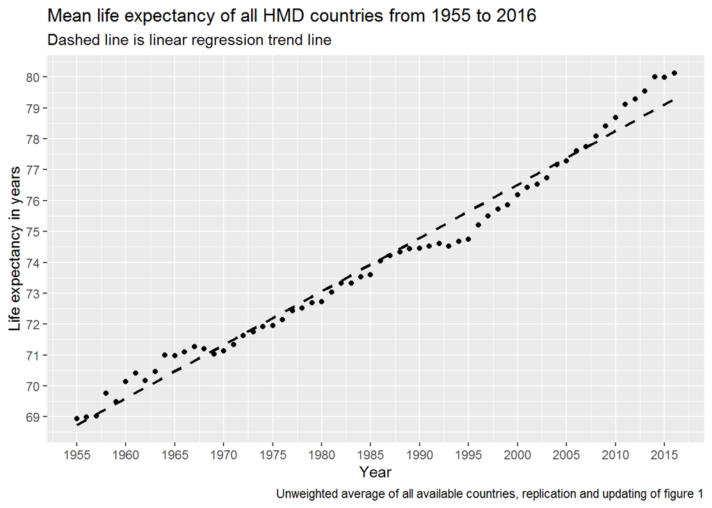

```r
tmp <- dta_e0 %>%
  filter(code %in% all_distinct_countries) %>%
  filter(sex == "total") %>%
  filter(between(year, 1955, 2016)) %>%
  group_by(year) %>%
  summarise(mean_e0 = mean(e0, na.rm = T)) %>%
  ungroup()

tmp %>%
  ggplot(aes(x = year, y = mean_e0)) +
  geom_point() +
  scale_x_continuous(breaks = seq(1955, 2015, by = 5)) +
  scale_y_continuous(breaks = seq(65, 85, by = 1)) +
  stat_smooth(method = "lm", se = F, colour = "black", linetype = "dashed") +
  labs(
    x = "Year",
    y = "Life expectancy in years",
    title = "Mean life expectancy of all HMD countries from 1955 to 2016",
    subtitle = "Dashed line is linear regression trend line",
    caption = "Unweighted average of all available countries, replication and updating of figure 1"
  )
```

```r
ggsave(here("figures", "e0_limits", "appendix", "fig_1_a_all_hmd.png"), height = 12, width = 20, units = "cm", dpi = 300)
```

The fit is clearly less linear over time. This is likely due to changing composition of the countries over time, perhaps due to many Eastern European countries appearing post 1990ish, pulling the average down, but then increasing quickly thereafter.

Again, what’s the $R^2$ overall and by decade?

```r
tmp %>%
  lm(mean_e0 ~ year, data = .) %>%
  summary()
```

```
##
## Call:
## lm(formula = mean_e0 ~ year, data = .)
##
## Residuals:
##     Min      1Q  Median      3Q     Max
## -0.9060 -0.2633 -0.1033  0.3063  1.0559
##
## Coefficients:
##               Estimate Std. Error t value Pr(>|t|)
## (Intercept) -2.694e+02  6.247e+00  -43.12   <2e-16 ***
## year         1.729e-01  3.146e-03   54.97   <2e-16 ***
## ---
## Signif. codes:  0 '***' 0.001 '**' 0.01 '*' 0.05 '.' 0.1 ' ' 1
##
## Residual standard error: 0.4433 on 60 degrees of freedom
## Multiple R-squared:  0.9805, Adjusted R-squared:  0.9802
## F-statistic:  3021 on 1 and 60 DF,  p-value: < 2.2e-16
```

Now the $R^2$ is ‘only’ around 0.98.

What does this look like for the earlier and later period?

```r
tmp %>%
  lm(mean_e0 ~ year, .) %>%
  summary()
```

```
##
## Call:
## lm(formula = mean_e0 ~ year, data = .)
##
## Residuals:
##     Min      1Q  Median      3Q     Max
## -0.9060 -0.2633 -0.1033  0.3063  1.0559
##
## Coefficients:
##               Estimate Std. Error t value Pr(>|t|)
## (Intercept) -2.694e+02  6.247e+00  -43.12   <2e-16 ***
## year         1.729e-01  3.146e-03   54.97   <2e-16 ***
## ---
## Signif. codes:  0 '***' 0.001 '**' 0.01 '*' 0.05 '.' 0.1 ' ' 1
##
## Residual standard error: 0.4433 on 60 degrees of freedom
## Multiple R-squared:  0.9805, Adjusted R-squared:  0.9802
## F-statistic:  3021 on 1 and 60 DF,  p-value: < 2.2e-16
```

```r
tmp %>%
  filter(year < 1993) %>%
  lm(mean_e0 ~ year, .) %>%
  summary()
```

```
##
## Call:
## lm(formula = mean_e0 ~ year, data = .)
##
## Residuals:
##     Min      1Q  Median      3Q     Max
## -0.4116 -0.1680 -0.0534  0.1748  0.4978
##
## Coefficients:
##               Estimate Std. Error t value Pr(>|t|)
## (Intercept) -2.278e+02  6.319e+00  -36.06   <2e-16 ***
## year         1.519e-01  3.202e-03   47.45   <2e-16 ***
## ---
## Signif. codes:  0 '***' 0.001 '**' 0.01 '*' 0.05 '.' 0.1 ' ' 1
##
## Residual standard error: 0.2164 on 36 degrees of freedom
## Multiple R-squared:  0.9843, Adjusted R-squared:  0.9838
## F-statistic:  2251 on 1 and 36 DF,  p-value: < 2.2e-16
```

```r
tmp %>%
  filter(year >= 1993) %>%
  lm(mean_e0 ~ year, .) %>%
  summary()
```

```
##
## Call:
## lm(formula = mean_e0 ~ year, data = .)
##
## Residuals:
##       Min        1Q    Median        3Q       Max
## -0.187436 -0.101846  0.000075  0.079855  0.272944
##
## Coefficients:
##               Estimate Std. Error t value Pr(>|t|)
## (Intercept) -4.341e+02  7.072e+00  -61.39   <2e-16 ***
## year         2.551e-01  3.528e-03   72.32   <2e-16 ***
## ---
## Signif. codes:  0 '***' 0.001 '**' 0.01 '*' 0.05 '.' 0.1 ' ' 1
##
## Residual standard error: 0.1196 on 22 degrees of freedom
## Multiple R-squared:  0.9958, Adjusted R-squared:  0.9956
## F-statistic:  5230 on 1 and 22 DF,  p-value: < 2.2e-16
```

Since 1993, the improvement for all available countries has been almost perfect ($R^2$ > 0.99), with an average improvement of around 0.255 years/year. This is a general phemomena, not confined to historically rich nations.

And again, by decade

```r
dta_e0 %>%
  filter(code %in% all_distinct_countries) %>%
  filter(sex == "total") %>%
  filter(between(year, 1955, 2016)) %>%
  mutate(decade = cut(year, seq(1955, 2015, by = 10), include.lowest = TRUE)) %>%
  group_by(year, decade) %>%
  summarise(mean_e0 = mean(e0, na.rm = T)) %>%
  group_by(decade) %>%
  nest() %>%
  filter(!is.na(decade)) %>%
  mutate(mod = map(data, ~lm(mean_e0 ~ I(year - min(year)), data = .))) %>%
  mutate(tdy_mod = map(mod, broom::tidy)) %>%
  select(decade, tdy_mod) %>%
  unnest()
```

| decade | term | estimate | std.error | statistic | p.value |
| --- | --- | --- | --- | --- | --- |
| [1955,1965] | (Intercept) | 68.84128332 | 0.119532395 | 575.921561 | 7.303862e-22 |
| [1955,1965] | I(year - min(year)) | 0.22010790 | 0.020204662 | 10.893916 | 1.746938e-06 |
| (1965,1975] | (Intercept) | 70.96776134 | 0.097254566 | 729.711359 | 1.393111e-20 |
| (1965,1975] | I(year - min(year)) | 0.10292381 | 0.018217449 | 5.649738 | 4.815703e-04 |
| (1975,1985] | (Intercept) | 72.19028569 | 0.048102973 | 1500.744773 | 4.352690e-23 |
| (1975,1985] | I(year - min(year)) | 0.16423905 | 0.009010512 | 18.227492 | 8.437134e-08 |
| (1985,1995] | (Intercept) | 74.15406110 | 0.040453965 | 1833.048038 | 8.786654e-24 |
| (1985,1995] | I(year - min(year)) | 0.06726892 | 0.007577722 | 8.877196 | 2.049841e-05 |
| (1995,2005] | (Intercept) | 75.23910469 | 0.039162276 | 1921.213811 | 6.034052e-24 |
| (1995,2005] | I(year - min(year)) | 0.22757165 | 0.007335766 | 31.022205 | 1.267339e-09 |

[output cut: 2 more lines]

- From 1955-1964 the average improvement was 0.220 years/year.
- From 1965-1974 the average improvement was 0.103 years/year.
- From 1975-1984 the average improvement was 0.164 years/year.
- From 1985-1994 the average improvement was 0.067 years/year.
- From 1995-2004 the average improvement was 0.228 years/year.
- From 2005-2014 the average improvement was 0.287 years/year.

The expansion of the range of countries in the HMD appears to have led to a slowdown from 1985-1994, but this is almost certainly compositional rather than genuine for any particular country. From 2005-2014 the average rate of improvement was faster than in the previous decadal period.

And as a more nicely formatted table

```r
dta_e0 %>%
  filter(code %in% all_distinct_countries) %>%
  filter(sex == "total") %>%
  filter(between(year, 1955, 2016)) %>%
  mutate(decade = cut(year, seq(1955, 2015, by = 10), include.lowest = TRUE)) %>%
  group_by(year, decade) %>%
  summarise(mean_e0 = mean(e0, na.rm = T)) %>%
  group_by(decade) %>%
  nest() %>%
  filter(!is.na(decade)) %>%
  mutate(mod = map(data, ~lm(mean_e0 ~ I(year - min(year)), data = .))) %>%
  mutate(tdy_mod = map(mod, broom::tidy)) %>%
  select(decade, tdy_mod) %>%
  unnest() %>%
  mutate(text = glue::glue(
    "{show_2dp(estimate)} [{show_2dp(estimate - 2 * std.error)} to {show_2dp(estimate + 2 * std.error)}]"
   )
  ) %>%
  select(decade, term, text) %>%
  spread(term, text) %>%
  rename(
    `Decade` = `decade`,
    `Life expectancy at start of decade (+/- 2 SEs)` = `(Intercept)`,
    `Mean gain in life expectancy per year (+/- 2 SEs)` = `I(year - min(year))`
  )
```

| Decade | Life expectancy at start of decade (+/- 2 SEs) | Mean gain in life expectancy per year (+/- 2 SEs) |
| --- | --- | --- |
| [1955,1965] | 68.84 [68.60 to 69.08] | 0.22 [ 0.18 to 0.26] |
| (1965,1975] | 70.97 [70.77 to 71.16] | 0.10 [ 0.07 to 0.14] |
| (1975,1985] | 72.19 [72.09 to 72.29] | 0.16 [ 0.15 to 0.18] |
| (1985,1995] | 74.15 [74.07 to 74.23] | 0.07 [ 0.05 to 0.08] |
| (1995,2005] | 75.24 [75.16 to 75.32] | 0.23 [ 0.21 to 0.24] |
| (2005,2015] | 77.56 [77.45 to 77.67] | 0.29 [ 0.27 to 0.31] |

Let’s look at how the UK compares with this.

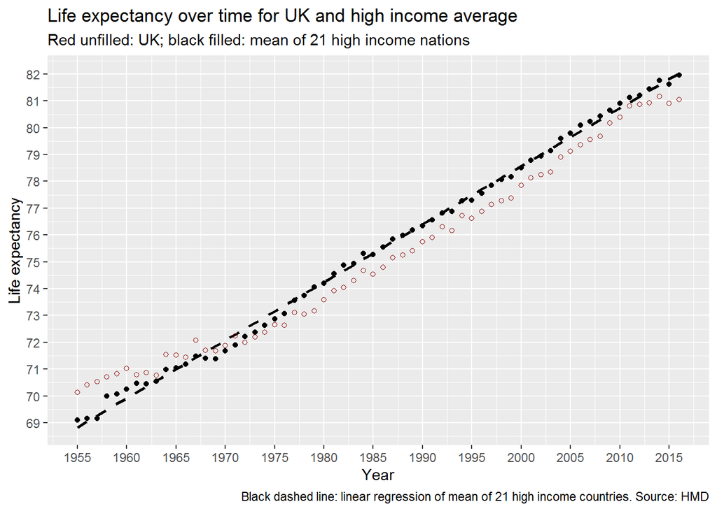

```r
tmp <- dta_e0 %>%
  filter(code %in% high_income_countries) %>%
  filter(sex == "total") %>%
  filter(between(year, 1955, 2016)) %>%
  group_by(year) %>%
  summarise(mean_e0 = mean(e0, na.rm = T)) %>%
  ungroup()

tmp %>%
  ggplot(aes(x = year, y = mean_e0)) +
  geom_point() +
  stat_smooth(method = "lm", se = F, colour = "black", linetype = "dashed") +
  scale_x_continuous(breaks = seq(1955, 2015, by = 5)) +
  scale_y_continuous(breaks = seq(65, 85, by = 1)) +
  geom_point(
    aes(x = year, y = e0),
    inherit.aes = F,
    data = dta_e0 %>%
      filter(sex == "total") %>%
      filter(code == "GBR_NP") %>%
      filter(between(year, 1955, 2016)) ,
    colour = "darkred", shape = 1
  ) +
  labs(
    x = "Year",
    y = "Life expectancy",
    title = "Life expectancy over time for UK and high income average",
    subtitle = "Red unfilled: UK; black filled: mean of 21 high income nations",
    caption = "Black dashed line: linear regression of mean of 21 high income countries. Source: HMD"

  )
```

```r
ggsave(here("figures", "pt1_white_update_uk.png"), height = 12, width = 20, units = "cm", dpi = 300)
ggsave(here("figures", "e0_limits", "fig_01_b_highincomeuk.png"), height = 12, width = 20, units = "cm", dpi = 300)
```